# Introduction of WeatherBitRWrapper

## **Getting Started**

Before start using `WeatherBitRWrapper`. You need to set up your Weatherbit API Key.

1. Go to Weatherbit [API website](https://www.weatherbit.io/).
2. Sign up and you will get your API key.

Set your API key into your `.Renviron` file.

1. Opening the `.Renviron` file in RStudio using `file.edit("~/.Renviron")`
2. Add `WEATHERBIT_API_KEY=your_actual_api_key_here` and saving the file.

Next, you can ready to enjoy calling `WeatherBitRWrapper` by run the following code:

```r
# Load the package
library(WeatherBitRWrapper)
```

The following workflow diagram illustrates the overall structure of the package, detailing how user inputs are processed through various function categories to interact with the **WeatherBit API** and return structured outputs.

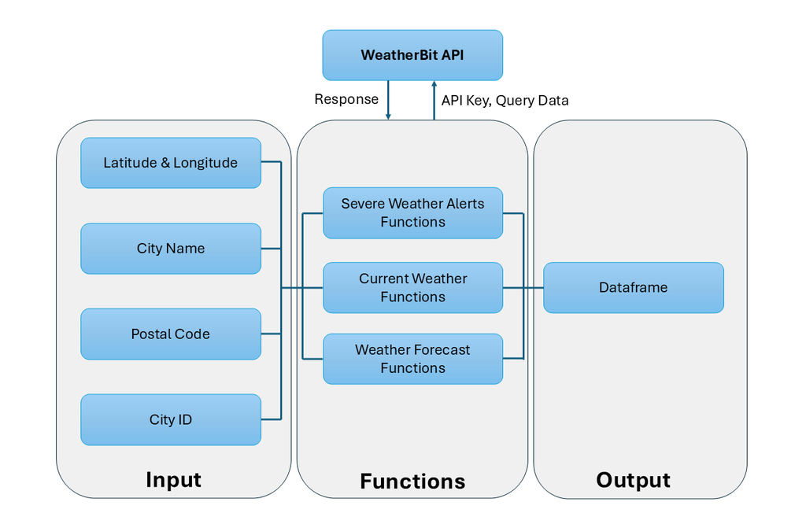

WeatherBitRWrapper Workflow

## Fetch Current Weather

There are 3 methods to fetch current weather data. A dataframe with key weather information will be returned.

- `get_current_temperature`: Get current temperature, feels-like temperature, and dew point.
- `get_current_wind`: Get wind speed, direction, and gusts.
- `get_current_precipitation`: Get precipitation, humidity, and cloud coverage.

**Common arguments**:

- `location`: A **string** representing the location. It can be one of:
  - A **city name** (e.g., `"Vancouver"`)
  - A **latitude/longitude pair** (e.g., `"49.28,-123.12"`)
  - A **postal code** (e.g., `"V6B1H6"`)
- `by`: A **string** specifying the location type. Choose from:
  - `"city"` for a city name.
  - `"latlon"` for latitude/longitude.
  - `"postal"` for a postal code.
- `save_dir`: (Optional) **String**. If provided, saves the result as a `.csv` file at the given directory.

### Get Current Temperature by location

```r
get_current_temperature(location, by = "city", save_dir = "")
```

**Example**:

```r
# Fetch current temperature in Vancouver
df <- WeatherBitRWrapper::get_current_temperature("Vancouver")

kable(df) %>%
  kable_styling(bootstrap_options = "striped", full_width = FALSE) %>%
  scroll_box(height = "100px")
```

| city | country | temperature_C | feels_like_C | dew_point_C |
| --- | --- | --- | --- | --- |
| Vancouver | CA | 8.3 | 8.4 | -0.1 |

### Get Current Wind by location

```r
get_current_wind(location, by = "city", save_dir = "")
```

**Example**:

```r
# Fetch current wind data in Vancouver
df <- WeatherBitRWrapper::get_current_wind("Vancouver")

kable(df) %>%
  kable_styling(bootstrap_options = "striped", full_width = FALSE) %>%
  scroll_box(height = "100px")
```

| city | country | wind_speed_mps | wind_direction | wind_gusts_mps |
| --- | --- | --- | --- | --- |
| Vancouver | CA | 4.6 | west-northwest | 9.2 |

### Get Current Precipitation by location

```r
get_current_precipitation(location, by = "city", save_dir = "")
```

**Example**:

```r
# Fetch current precipitation data in Vancouver
df <- WeatherBitRWrapper::get_current_precipitation("Vancouver")

kable(df) %>%
  kable_styling(bootstrap_options = "striped", full_width = FALSE) %>%
  scroll_box(height = "100px")
```

| city | country | precipitation_mm | humidity_percent | cloud_coverage_percent |
| --- | --- | --- | --- | --- |
| Vancouver | CA | 0 | 56 | 33 |

## Fetch Alert

There are 4 methods to fetch severe weather alerts data. A dataframe with detailed alerts information will be return.

- `weather_alert_lat`: Get alerts by latitude and longitude.
- `weather_alert_city`: Get alerts by city name.
- `weather_alert_postal`: Get alerts by postal code.
- `weather_alert_id`: Get alerts by city id.

**Common arguments**:

- `save_dir`: Directory path, default at ’’. To save query result as a dataframe, assign `save_dir` a valid directory path.

### Get alerts by latitude and longitude

```r
weather_alert_lat <- (
  lat, lon, save_dir = ''
  )
```

**Example**:

```r
# Fetch weather alerts at [49.88307, 119.48568]

df <- WeatherBitRWrapper::weather_alert_lat(lat=49.88307, lon=119.48568)
```

```
#> [1] "Connected to WeatherBit API successfully!"
#> No active weather alerts for the location.
```

```r
kable(df) %>%
  kable_styling(bootstrap_options = "striped", full_width = FALSE) %>%
  scroll_box(height = "100px")
```

| city_name | state_code | country_code | lat | lon | timezone | title | severity | effective_local | expires_local | regions | uri |
| --- | --- | --- | --- | --- | --- | --- | --- | --- | --- | --- | --- |
| Heishantou | 20 | CN | 49.8831 | 119.4857 | Asia/Shanghai | NA | NA | NA | NA | NA | NA |

### Get alerts by city name

```r
weather_alert_city <- (
  city, state = NULL, country = NULL, save_dir = ''
  )
```

**Example**:

```r
# Fetch weather alerts in Kelowna

df <- WeatherBitRWrapper::weather_alert_city(city="Kelowna")
```

```
#> [1] "Connected to WeatherBit API successfully!"
#> No active weather alerts for the location.
```

```r
kable(df) %>%
  kable_styling(bootstrap_options = "striped", full_width = FALSE) %>%
  scroll_box(height = "100px")
```

| city_name | state_code | country_code | lat | lon | timezone | title | severity | effective_local | expires_local | regions | uri |
| --- | --- | --- | --- | --- | --- | --- | --- | --- | --- | --- | --- |
| Kelowna | BC | CA | 49.88307 | -119.4857 | America/Vancouver | NA | NA | NA | NA | NA | NA |

```r
# Fetch weather alerts in Kelowna, BC

df <- WeatherBitRWrapper::weather_alert_city(city="Kelowna", state="BC")
```

```
#> [1] "Connected to WeatherBit API successfully!"
#> No active weather alerts for the location.
```

```r
kable(df) %>%
  kable_styling(bootstrap_options = "striped", full_width = FALSE) %>%
  scroll_box(height = "100px")
```

| city_name | state_code | country_code | lat | lon | timezone | title | severity | effective_local | expires_local | regions | uri |
| --- | --- | --- | --- | --- | --- | --- | --- | --- | --- | --- | --- |
| Kelowna | BC | CA | 49.88307 | -119.4857 | America/Vancouver | NA | NA | NA | NA | NA | NA |

```r
# Fetch weather alerts in Kelowna, BC, Canada

df <- WeatherBitRWrapper::weather_alert_city(city="Kelowna", state="BC", country="CA")
```

```
#> [1] "Connected to WeatherBit API successfully!"
#> No active weather alerts for the location.
```

```r
kable(df) %>%
  kable_styling(bootstrap_options = "striped", full_width = FALSE) %>%
  scroll_box(height = "100px")
```

| city_name | state_code | country_code | lat | lon | timezone | title | severity | effective_local | expires_local | regions | uri |
| --- | --- | --- | --- | --- | --- | --- | --- | --- | --- | --- | --- |
| Kelowna | BC | CA | 49.88307 | -119.4857 | America/Vancouver | NA | NA | NA | NA | NA | NA |

### Get alerts by postal code

```r
weather_alert_postal <- (
  postal_code, country = NULL, save_dir = ''
  )
```

**Example**:

```r
# Fetch weather alerts at V1V1V7

df <- WeatherBitRWrapper::weather_alert_postal(postal_code="V1V1V7")
```

```
#> [1] "Connected to WeatherBit API successfully!"
#> No active weather alerts for the location.
```

```r
kable(df) %>%
  kable_styling(bootstrap_options = "striped", full_width = FALSE) %>%
  scroll_box(height = "100px")
```

| city_name | state_code | country_code | lat | lon | timezone | title | severity | effective_local | expires_local | regions | uri |
| --- | --- | --- | --- | --- | --- | --- | --- | --- | --- | --- | --- |
| Kelowna | BC | CA | 49.9497 | -119.4339 | America/Vancouver | NA | NA | NA | NA | NA | NA |

```r
# Fetch weather alerts at V1V1V7, Canada

df <- WeatherBitRWrapper::weather_alert_postal(postal_code="V1V1V7", country="CA")
```

```
#> [1] "Connected to WeatherBit API successfully!"
#> No active weather alerts for the location.
```

```r
kable(df) %>%
  kable_styling(bootstrap_options = "striped", full_width = FALSE) %>%
  scroll_box(height = "100px")
```

| city_name | state_code | country_code | lat | lon | timezone | title | severity | effective_local | expires_local | regions | uri |
| --- | --- | --- | --- | --- | --- | --- | --- | --- | --- | --- | --- |
| Kelowna | BC | CA | 49.9497 | -119.4339 | America/Vancouver | NA | NA | NA | NA | NA | NA |

### Get alerts by city id

```r
weather_alert_id <- (
  city_id, save_dir = ''
  )
```

**Example**:

```r
# Fetch weather alerts at 8953360

df <- WeatherBitRWrapper::weather_alert_id(city_id=8953360)
```

```
#> [1] "Connected to WeatherBit API successfully!"
```

```r
kable(df) %>%
  kable_styling(bootstrap_options = "striped", full_width = FALSE) %>%
  scroll_box(height = "100px")
```

| description | effective_local | effective_utc | ends_local | ends_utc | expires_local | expires_utc | onset_local | onset_utc | regions | severity | title | uri | city_name | state_code | country_code | lat | lon | timezone |
| --- | --- | --- | --- | --- | --- | --- | --- | --- | --- | --- | --- | --- | --- | --- | --- | --- | --- | --- |
| English(en-GB): Moderate intensity weather phenomena expected coasts (DISCLAIMER: “Information provided on METEOALARM for Italy regard only the intensity and recurrence of the phenomena, further detai… | \|2025-03-18T01:00:00 | \|2025-03-18T00:00:00 | \|2025-03-18T12:59:00 | \|2025-03-18T11:59:00 | \|2025-03-18T12:59:00 | \|2025-03-18T11:59:00 | \|2025-03-18T01:00:00 | \|2025-03-18T00:00:00 | \|Veneto,IT | \|Advisory | \|Wind | \|https://meteoalarm.org?geocode=EMMA_ID:IT006 | \|Comugne | \|20 | \|IT | 45.7818 |  |  |

## Fetch Forecast Weather

There are 4 methods to fetch forecast weather data. A dataframe with forecast data will be return.

- `get_forecast_by_city`: Get forecast weather by city name.
- `get_forecast_by_lat_lon`: Get forecast weather by latitude and longitude. (Recommended)
- `get_forecast_by_postal_code`: Get forecast weather by postal.
- `get_forecast_by_city_id`: Get forecast by city id.

**Common arguments**:

- `save_dir`: Directory path, default at ’’. To save query result as a dataframe, assign `save_dir` a valid directory path.
- `language`: Weatherbit API supports a list of language as return. `English` is the default language.Other available options: Available language list:
  - `en` - [DEFAULT] English
  - `ar` - Arabic
  - `az` - Azerbaijani
  - `be` - Belarusian
  - `bg` - Bulgarian
  - `bs` - Bosnian
  - `ca` - Catalan
  - `cz` - Czech
  - `da` - Danish
  - `de` - German
  - `fi` - Finnish
  - `fr` - French
  - `el` - Greek
  - `es` - Spanish
  - `et` - Estonian
  - `ja` - Japanese
  - `hr` - Croation
  - `hu` - Hungarian
  - `id` - Indonesian
  - `it` - Italian
  - `is` - Icelandic
  - `iw` - Hebrew
  - `kw` - Cornish
  - `lt` - Lithuanian
  - `nb` - Norwegian Bokmål
  - `nl` - Dutch
  - `pl` - Polish
  - `pt` - Portuguese
  - `ro` - Romanian
  - `ru` - Russian
  - `sk` - Slovak
  - `sl` - Slovenian
  - `sr` - Serbian
  - `sv` - Swedish
  - `tr` - Turkish
  - `uk` - Ukrainian
  - `zh` - Chinese (Simplified)
  - `zh`-tw - Chinese (Traditional)
- `unit`: Unit used in weather results. Default as `Metric (Celsius, m/s, mm)`. Other options:
  - `M` - [DEFAULT] Metric (Celsius, m/s, mm)
  - `S` - Scientific (Kelvin, m/s, mm)
  - `I` - Fahrenheit (F, mph, in).
- `day`: A specific number of forecast days. Default as 16. The max number is 16.

### Get forecast weather by city name

```r
get_forecast_by_city <- (
  city, save_dir = '', language = 'en', unit = 'M', day = 16
  )
```

**Example**:

```r
# Fetch next 16 days weather in Raleigh, NC.

df <- WeatherBitRWrapper::get_forecast_by_city("Raleigh,NC")
```

```
#> [1] "Connect WeatherBit API success!"
```

```r
kable(df[1:16, ]) %>%
  kable_styling(bootstrap_options = "striped", full_width = FALSE) %>%
  scroll_box(height = "300px")
```

| city_name | country_code | data.app_max_temp | data.app_min_temp | data.clouds | data.clouds_hi | data.clouds_low | data.clouds_mid | data.datetime | data.dewpt | data.high_temp | data.low_temp | data.max_dhi | data.max_temp | data.min_temp | data.moon_phase | data.moon_phase_lunation | data.moonrise_ts | data.moonset_ts | data.ozone | data.pop | data.precip | data.pres | data.rh | data.slp | data.snow | data.snow_depth | data.sunrise_ts | data.sunset_ts | data.temp | … |
| --- | --- | --- | --- | --- | --- | --- | --- | --- | --- | --- | --- | --- | --- | --- | --- | --- | --- | --- | --- | --- | --- | --- | --- | --- | --- | --- | --- | --- | --- | --- |
| Raleigh | US | 14.1 | 8.6 | 43 | 0 | 40 | 14 | 2025-03-17 | 6.3 | 15.1 | 2.8 | NA | 15.1 | 7.9 | 0.84 | 0.61 | 1742262609 | 1742217060 | 377 | 35 | 1.0000 | 1003 | 67 | 1015 | 0 | 0 | 1742210472 | 1742253875 | 12.5 | … |
| Raleigh | US | 18.4 | 2.0 | 2 | 0 | 0 | 0 | 2025-03-18 | 0.9 | 20.4 | 7.4 | NA | 20.4 | 2.8 | 0.77 | 0.64 | 1742352534 | 1742305351 | 307 | 0 | 0.0000 | 1010 | 53 | 1022 | 0 | 0 | 1742296786 | 1742340326 | 11.0 | … |
| Raleigh | US | 23.8 | 8.0 | 25 | 52 | 2 | 0 | 2025-03-19 | 5.9 | 25.0 | 11.2 | NA | 25.0 | 7.2 | 0.68 | 0.68 | 1742442534 | 1742394006 | 275 | 0 | 0.0000 | 1007 | 55 | 1019 | 0 | 0 | 1742383099 | 1742426777 | 15.5 | … |
| Raleigh | US | 20.5 | 10.1 | 57 | 55 | 36 | 45 | 2025-03-20 | 7.2 | 21.9 | 3.6 | NA | 21.9 | 8.8 | 0.59 | 0.71 | 1742446177 | 1742483115 | 292 | 50 | 2.7200 | 997 | 59 | 1009 | 0 | 0 | 1742469413 | 1742513228 | 15.1 | … |
| Raleigh | US | 13.9 | 0.8 | 8 | 17 | 2 | 19 | 2025-03-21 | -2.1 | 14.5 | 5.2 | NA | 14.5 | 3.1 | 0.48 | 0.75 | 1742536171 | 1742572724 | 352 | 10 | 0.2400 | 1004 | 46 | 1016 | 0 | 0 | 1742555726 | 1742599679 | 9.1 | … |
| Raleigh | US | 18.0 | 3.7 | 29 | 13 | 15 | 65 | 2025-03-22 | 1.6 | 19.6 | 8.3 | NA | 18.9 | 5.0 | 0.38 | 0.78 | 1742625985 | 1742662800 | 352 | 0 | 0.0000 | 1004 | 52 | 1016 | 0 | 0 | 1742642040 | 1742686130 | 11.4 | … |
| Raleigh | US | 18.3 | 7.9 | 8 | 26 | 0 | 5 | 2025-03-23 | 3.8 | 18.3 | 10.8 | NA | 18.3 | 7.9 | 0.27 | 0.81 | 1742715490 | 1742753224 | 348 | 0 | 0.0000 | 1008 | 56 | 1020 | 0 | 0 | 1742728353 | 1742772581 | 12.8 | … |
| Raleigh | US | 21.1 | 10.8 | 83 | 88 | 46 | 63 | 2025-03-24 | 11.3 | 21.3 | 15.5 | NA | 21.3 | 10.8 | 0.18 | 0.85 | 1742804612 | 1742843846 | 323 | 50 | 3.0625 | 1004 | 74 | 1016 | 0 | 0 | 1742814666 | 1742859031 | 16.0 | … |
| Raleigh | US | 16.7 | 7.8 | 94 | 93 | 83 | 72 | 2025-03-25 | 8.4 | 16.7 | 5.1 | NA | 16.7 | 7.8 | 0.09 | 0.88 | 1742893361 | 1742934550 | 334 | 80 | 8.8125 | 1003 | 75 | 1015 | 0 | 0 | 1742900979 | 1742945482 | 13.0 | … |
| Raleigh | US | 15.1 | 1.3 | 2 | 0 | 2 | 0 | 2025-03-26 | 0.3 | 15.1 | 5.8 | NA | 15.1 | 5.1 | 0.03 | 0.92 | 1742981804 | 1743025285 | 389 | 0 | 0.0000 | 1008 | 56 | 1020 | 0 | 0 | 1742987293 | 1743031933 | 9.5 | … |
| Raleigh | US | 13.7 | 4.5 | 2 | 1 | 1 | 0 | 2025-03-27 | 0.2 | 15.1 | 12.3 | NA | 15.1 | 5.8 | 0.00 | 0.95 | 1743070035 | 1743116062 | 383 | 0 | 0.0000 | 1013 | 57 | 1025 | 0 | 0 | 1743073606 | 1743118383 | 8.3 | … |
| Raleigh | US | 15.5 | 9.5 | 22 | 50 | 0 | 22 | 2025-03-28 | 5.8 | 17.1 | 14.0 | NA | 17.1 | 8.5 | 0.01 | 0.98 | 1743158156 | 1743206921 | 326 | 0 | 0.0000 | 1015 | 64 | 1027 | 0 | 0 | 1743159920 | 1743204833 | 12.5 | … |
| Raleigh | US | 16.9 | 11.8 | 93 | 100 | 3 | 93 | 2025-03-29 | 10.2 | 18.5 | 15.2 | NA | 18.5 | 10.6 | 0.01 | 0.02 | 1743246268 | 1743293321 | 332 | 20 | 0.1250 | 1012 | 77 | 1024 | 0 | 0 | 1743246233 | 1743291284 | 14.3 | … |
| Raleigh | US | 19.8 | 13.8 | 54 | 53 | 42 | 3 | 2025-03-30 | 13.3 | 21.9 | 17.9 | NA | 21.9 | 12.4 | 0.04 | 0.05 | 1743334478 | 1743384294 | 332 | 0 | 0.0000 | 1011 | 81 | 1022 | 0 | 0 | 1743332547 | 1743377734 | 16.8 | … |
| Raleigh | US | 22.6 | 16.5 | 2 | 8 | 0 | 0 | 2025-03-31 | 14.5 | 24.9 | 20.4 | NA | 24.9 | 14.8 | 0.11 | 0.09 | 1743422905 | 1743475353 | 314 | 0 | 0.0000 | 1008 | 73 | 1019 | 0 | 0 | 1743418861 | 1743464185 | 19.6 | … |
| Raleigh | US | 24.5 | 17.6 | 13 | 50 | 1 | 0 | 2025-04-01 | 15.7 | 26.8 | 22.0 | NA | 26.8 | 15.8 | 0.19 | 0.12 | 1743511675 | 1743566364 | 303 | 0 | 0.0000 | 1012 | 73 | 1024 | 0 | 0 | 1743505176 | 1743550635 | 21.0 | … |

Example to draw a temperature line chart

```r
library(ggplot2)

# Fetch forecast data in Raleigh,NC
weather_data <- WeatherBitRWrapper::get_forecast_by_city("Raleigh,NC", save_dir = './')
```

```
#> [1] "Connect WeatherBit API success!"
#> File forecast_Raleigh_2025-03-17_2025-04-01.csv saved successfully into ./forecast_Raleigh_2025-03-17_2025-04-01.csv.
```

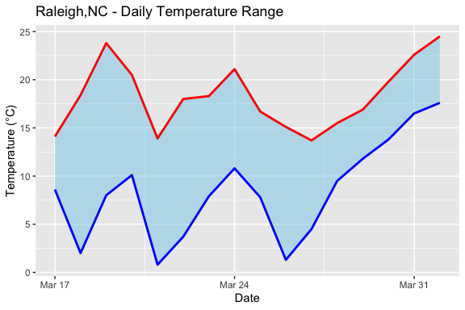

```r
# Convert date format.
weather_data$data.datetime <- as.Date(weather_data$data.datetime)

# Create an area chart
ggplot(weather_data, aes(x = data.datetime)) +
  geom_ribbon(aes(ymin = data.app_min_temp, ymax = data.app_max_temp), fill = "skyblue", alpha = 0.5) +
  geom_line(aes(y = data.app_max_temp), color = "red", linewidth = 1) +   # High temp line
  geom_line(aes(y = data.app_min_temp), color = "blue", linewidth = 1) +   # Low temp line
  labs(title = "Raleigh,NC - Daily Temperature Range",
       x = "Date",
       y = "Temperature (°C)")
```

```r
# Fetch next 16 days weather in Raleigh, NC in French.

df <- WeatherBitRWrapper::get_forecast_by_city("Raleigh,NC", language = "fr")
```

```
#> [1] "Connect WeatherBit API success!"
```

```r
kable(df[1:16, ]) %>%
  kable_styling(bootstrap_options = "striped", full_width = FALSE) %>%
  scroll_box(height = "300px")
```

| city_name | country_code | data.app_max_temp | data.app_min_temp | data.clouds | data.clouds_hi | data.clouds_low | data.clouds_mid | data.datetime | data.dewpt | data.high_temp | data.low_temp | data.max_dhi | data.max_temp | data.min_temp | data.moon_phase | data.moon_phase_lunation | data.moonrise_ts | data.moonset_ts | data.ozone | data.pop | data.precip | data.pres | data.rh | data.slp | data.snow | data.snow_depth | data.sunrise_ts | data.sunset_ts | data.temp | … |
| --- | --- | --- | --- | --- | --- | --- | --- | --- | --- | --- | --- | --- | --- | --- | --- | --- | --- | --- | --- | --- | --- | --- | --- | --- | --- | --- | --- | --- | --- | --- |
| Raleigh | US | 14.1 | 8.6 | 43 | 0 | 40 | 14 | 2025-03-17 | 6.3 | 15.1 | 2.8 | NA | 15.1 | 7.9 | 0.84 | 0.61 | 1742262609 | 1742217060 | 377 | 35 | 1.0000 | 1003 | 67 | 1015 | 0 | 0 | 1742210472 | 1742253875 | 12.5 | … |
| Raleigh | US | 18.4 | 2.0 | 2 | 0 | 0 | 0 | 2025-03-18 | 0.9 | 20.4 | 7.4 | NA | 20.4 | 2.8 | 0.77 | 0.64 | 1742352534 | 1742305351 | 307 | 0 | 0.0000 | 1010 | 53 | 1022 | 0 | 0 | 1742296786 | 1742340326 | 11.0 | … |
| Raleigh | US | 23.8 | 8.0 | 25 | 52 | 2 | 0 | 2025-03-19 | 5.9 | 25.0 | 11.2 | NA | 25.0 | 7.2 | 0.68 | 0.68 | 1742442534 | 1742394006 | 275 | 0 | 0.0000 | 1007 | 55 | 1019 | 0 | 0 | 1742383099 | 1742426777 | 15.5 | … |
| Raleigh | US | 20.5 | 10.1 | 57 | 55 | 36 | 45 | 2025-03-20 | 7.2 | 21.9 | 3.6 | NA | 21.9 | 8.8 | 0.59 | 0.71 | 1742446177 | 1742483115 | 292 | 50 | 2.7200 | 997 | 59 | 1009 | 0 | 0 | 1742469413 | 1742513228 | 15.1 | … |
| Raleigh | US | 13.9 | 0.8 | 8 | 17 | 2 | 19 | 2025-03-21 | -2.1 | 14.5 | 5.2 | NA | 14.5 | 3.1 | 0.48 | 0.75 | 1742536171 | 1742572724 | 352 | 10 | 0.2400 | 1004 | 46 | 1016 | 0 | 0 | 1742555726 | 1742599679 | 9.1 | … |
| Raleigh | US | 18.0 | 3.7 | 29 | 13 | 15 | 65 | 2025-03-22 | 1.6 | 19.6 | 8.3 | NA | 18.9 | 5.0 | 0.38 | 0.78 | 1742625985 | 1742662800 | 352 | 0 | 0.0000 | 1004 | 52 | 1016 | 0 | 0 | 1742642040 | 1742686130 | 11.4 | … |
| Raleigh | US | 18.3 | 7.9 | 8 | 26 | 0 | 5 | 2025-03-23 | 3.8 | 18.3 | 10.8 | NA | 18.3 | 7.9 | 0.27 | 0.81 | 1742715490 | 1742753224 | 348 | 0 | 0.0000 | 1008 | 56 | 1020 | 0 | 0 | 1742728353 | 1742772581 | 12.8 | … |
| Raleigh | US | 21.1 | 10.8 | 83 | 88 | 46 | 63 | 2025-03-24 | 11.3 | 21.3 | 15.5 | NA | 21.3 | 10.8 | 0.18 | 0.85 | 1742804612 | 1742843846 | 323 | 50 | 3.0625 | 1004 | 74 | 1016 | 0 | 0 | 1742814666 | 1742859031 | 16.0 | … |
| Raleigh | US | 16.7 | 7.8 | 94 | 93 | 83 | 72 | 2025-03-25 | 8.4 | 16.7 | 5.1 | NA | 16.7 | 7.8 | 0.09 | 0.88 | 1742893361 | 1742934550 | 334 | 80 | 8.8125 | 1003 | 75 | 1015 | 0 | 0 | 1742900979 | 1742945482 | 13.0 | … |
| Raleigh | US | 15.1 | 1.3 | 2 | 0 | 2 | 0 | 2025-03-26 | 0.3 | 15.1 | 5.8 | NA | 15.1 | 5.1 | 0.03 | 0.92 | 1742981804 | 1743025285 | 389 | 0 | 0.0000 | 1008 | 56 | 1020 | 0 | 0 | 1742987293 | 1743031933 | 9.5 | … |
| Raleigh | US | 13.7 | 4.5 | 2 | 1 | 1 | 0 | 2025-03-27 | 0.2 | 15.1 | 12.3 | NA | 15.1 | 5.8 | 0.00 | 0.95 | 1743070035 | 1743116062 | 383 | 0 | 0.0000 | 1013 | 57 | 1025 | 0 | 0 | 1743073606 | 1743118383 | 8.3 | … |
| Raleigh | US | 15.5 | 9.5 | 22 | 50 | 0 | 22 | 2025-03-28 | 5.8 | 17.1 | 14.0 | NA | 17.1 | 8.5 | 0.01 | 0.98 | 1743158156 | 1743206921 | 326 | 0 | 0.0000 | 1015 | 64 | 1027 | 0 | 0 | 1743159920 | 1743204833 | 12.5 | … |
| Raleigh | US | 16.9 | 11.8 | 93 | 100 | 3 | 93 | 2025-03-29 | 10.2 | 18.5 | 15.2 | NA | 18.5 | 10.6 | 0.01 | 0.02 | 1743246268 | 1743293321 | 332 | 20 | 0.1250 | 1012 | 77 | 1024 | 0 | 0 | 1743246233 | 1743291284 | 14.3 | … |
| Raleigh | US | 19.8 | 13.8 | 54 | 53 | 42 | 3 | 2025-03-30 | 13.3 | 21.9 | 17.9 | NA | 21.9 | 12.4 | 0.04 | 0.05 | 1743334478 | 1743384294 | 332 | 0 | 0.0000 | 1011 | 81 | 1022 | 0 | 0 | 1743332547 | 1743377734 | 16.8 | … |
| Raleigh | US | 22.6 | 16.5 | 2 | 8 | 0 | 0 | 2025-03-31 | 14.5 | 24.9 | 20.4 | NA | 24.9 | 14.8 | 0.11 | 0.09 | 1743422905 | 1743475353 | 314 | 0 | 0.0000 | 1008 | 73 | 1019 | 0 | 0 | 1743418861 | 1743464185 | 19.6 | … |
| Raleigh | US | 24.5 | 17.6 | 13 | 50 | 1 | 0 | 2025-04-01 | 15.7 | 26.8 | 22.0 | NA | 26.8 | 15.8 | 0.19 | 0.12 | 1743511675 | 1743566364 | 303 | 0 | 0.0000 | 1012 | 73 | 1024 | 0 | 0 | 1743505176 | 1743550635 | 21.0 | … |

```r
# Fetch next 16 days weather in Raleigh, NC with Fahrenheit.

df <- WeatherBitRWrapper::get_forecast_by_city("Raleigh,NC", unit = 'I')
```

```
#> [1] "Connect WeatherBit API success!"
```

```r
kable(df[1:16, ]) %>%
  kable_styling(bootstrap_options = "striped", full_width = FALSE) %>%
  scroll_box(height = "300px")
```

| city_name | country_code | data.app_max_temp | data.app_min_temp | data.clouds | data.clouds_hi | data.clouds_low | data.clouds_mid | data.datetime | data.dewpt | data.high_temp | data.low_temp | data.max_dhi | data.max_temp | data.min_temp | data.moon_phase | data.moon_phase_lunation | data.moonrise_ts | data.moonset_ts | data.ozone | data.pop | data.precip | data.pres | data.rh | data.slp | data.snow | data.snow_depth | data.sunrise_ts | data.sunset_ts | data.temp | … |
| --- | --- | --- | --- | --- | --- | --- | --- | --- | --- | --- | --- | --- | --- | --- | --- | --- | --- | --- | --- | --- | --- | --- | --- | --- | --- | --- | --- | --- | --- | --- |
| Raleigh | US | 57.4 | 47.5 | 43 | 0 | 40 | 14 | 2025-03-17 | 43.3 | 59.2 | 37.0 | NA | 59.2 | 46.2 | 0.84 | 0.61 | 1742262609 | 1742217060 | 377 | 35 | 0.039 | 1003 | 67 | 1015 | 0 | 0 | 1742210472 | 1742253875 | 54.5 | … |
| Raleigh | US | 65.1 | 35.6 | 2 | 0 | 0 | 0 | 2025-03-18 | 33.6 | 68.7 | 45.3 | NA | 68.7 | 37.0 | 0.77 | 0.64 | 1742352534 | 1742305351 | 307 | 0 | 0.000 | 1010 | 53 | 1022 | 0 | 0 | 1742296786 | 1742340326 | 51.8 | … |
| Raleigh | US | 74.8 | 46.4 | 25 | 52 | 2 | 0 | 2025-03-19 | 42.6 | 77.0 | 52.2 | NA | 77.0 | 45.0 | 0.68 | 0.68 | 1742442534 | 1742394006 | 275 | 0 | 0.000 | 1007 | 55 | 1019 | 0 | 0 | 1742383099 | 1742426777 | 59.9 | … |
| Raleigh | US | 68.9 | 50.2 | 57 | 55 | 36 | 45 | 2025-03-20 | 45.0 | 71.4 | 38.5 | NA | 71.4 | 47.8 | 0.59 | 0.71 | 1742446177 | 1742483115 | 292 | 50 | 0.107 | 997 | 59 | 1009 | 0 | 0 | 1742469413 | 1742513228 | 59.2 | … |
| Raleigh | US | 57.0 | 33.4 | 8 | 17 | 2 | 19 | 2025-03-21 | 28.2 | 58.1 | 41.4 | NA | 58.1 | 37.6 | 0.48 | 0.75 | 1742536171 | 1742572724 | 352 | 10 | 0.009 | 1004 | 46 | 1016 | 0 | 0 | 1742555726 | 1742599679 | 48.4 | … |
| Raleigh | US | 64.4 | 38.7 | 29 | 13 | 15 | 65 | 2025-03-22 | 34.9 | 67.3 | 46.9 | NA | 66.0 | 41.0 | 0.38 | 0.78 | 1742625985 | 1742662800 | 352 | 0 | 0.000 | 1004 | 52 | 1016 | 0 | 0 | 1742642040 | 1742686130 | 52.5 | … |
| Raleigh | US | 64.9 | 46.2 | 8 | 26 | 0 | 5 | 2025-03-23 | 38.8 | 64.9 | 51.4 | NA | 64.9 | 46.2 | 0.27 | 0.81 | 1742715490 | 1742753224 | 348 | 0 | 0.000 | 1008 | 56 | 1020 | 0 | 0 | 1742728353 | 1742772581 | 55.0 | … |
| Raleigh | US | 70.0 | 51.4 | 83 | 88 | 46 | 63 | 2025-03-24 | 52.3 | 70.3 | 59.9 | NA | 70.3 | 51.4 | 0.18 | 0.85 | 1742804612 | 1742843846 | 323 | 50 | 0.121 | 1004 | 74 | 1016 | 0 | 0 | 1742814666 | 1742859031 | 60.8 | … |
| Raleigh | US | 62.1 | 46.0 | 94 | 93 | 83 | 72 | 2025-03-25 | 47.1 | 62.1 | 41.2 | NA | 62.1 | 46.0 | 0.09 | 0.88 | 1742893361 | 1742934550 | 334 | 80 | 0.347 | 1003 | 75 | 1015 | 0 | 0 | 1742900979 | 1742945482 | 55.4 | … |
| Raleigh | US | 59.2 | 34.3 | 2 | 0 | 2 | 0 | 2025-03-26 | 32.5 | 59.2 | 42.4 | NA | 59.2 | 41.2 | 0.03 | 0.92 | 1742981804 | 1743025285 | 389 | 0 | 0.000 | 1008 | 56 | 1020 | 0 | 0 | 1742987293 | 1743031933 | 49.1 | … |
| Raleigh | US | 56.7 | 40.1 | 2 | 1 | 1 | 0 | 2025-03-27 | 32.4 | 59.2 | 54.1 | NA | 59.2 | 42.4 | 0.00 | 0.95 | 1743070035 | 1743116062 | 383 | 0 | 0.000 | 1013 | 57 | 1025 | 0 | 0 | 1743073606 | 1743118383 | 46.9 | … |
| Raleigh | US | 59.9 | 49.1 | 22 | 50 | 0 | 22 | 2025-03-28 | 42.4 | 62.8 | 57.2 | NA | 62.8 | 47.3 | 0.01 | 0.98 | 1743158156 | 1743206921 | 326 | 0 | 0.000 | 1015 | 64 | 1027 | 0 | 0 | 1743159920 | 1743204833 | 54.5 | … |
| Raleigh | US | 62.4 | 53.2 | 93 | 100 | 3 | 93 | 2025-03-29 | 50.4 | 65.3 | 59.4 | NA | 65.3 | 51.1 | 0.01 | 0.02 | 1743246268 | 1743293321 | 332 | 20 | 0.005 | 1012 | 77 | 1024 | 0 | 0 | 1743246233 | 1743291284 | 57.7 | … |
| Raleigh | US | 67.6 | 56.8 | 54 | 53 | 42 | 3 | 2025-03-30 | 55.9 | 71.4 | 64.2 | NA | 71.4 | 54.3 | 0.04 | 0.05 | 1743334478 | 1743384294 | 332 | 0 | 0.000 | 1011 | 81 | 1022 | 0 | 0 | 1743332547 | 1743377734 | 62.2 | … |
| Raleigh | US | 72.7 | 61.7 | 2 | 8 | 0 | 0 | 2025-03-31 | 58.1 | 76.8 | 68.7 | NA | 76.8 | 58.6 | 0.11 | 0.09 | 1743422905 | 1743475353 | 314 | 0 | 0.000 | 1008 | 73 | 1019 | 0 | 0 | 1743418861 | 1743464185 | 67.3 | … |
| Raleigh | US | 76.1 | 63.7 | 13 | 50 | 1 | 0 | 2025-04-01 | 60.3 | 80.2 | 71.6 | NA | 80.2 | 60.4 | 0.19 | 0.12 | 1743511675 | 1743566364 | 303 | 0 | 0.000 | 1012 | 73 | 1024 | 0 | 0 | 1743505176 | 1743550635 | 69.8 | … |

### Get forecast weather by latitude and longitude

```r
get_forecast_by_lat_lon <- (
  lat, lon, save_dir = '', language = 'en', unit = 'M', day = 16
)
```

**Example**:

```r
# Fetch next 16 days weather in [38.123, 78.543].

df <- WeatherBitRWrapper::get_forecast_by_lat_lon(lat=38.123, lon=-78.543)
```

```
#> [1] "Connect WeatherBit API success!"
```

```r
kable(df[1:16, ]) %>%
  kable_styling(bootstrap_options = "striped", full_width = FALSE) %>%
  scroll_box(height = "300px")
```

| city_name | country_code | data.app_max_temp | data.app_min_temp | data.clouds | data.clouds_hi | data.clouds_low | data.clouds_mid | data.datetime | data.dewpt | data.high_temp | data.low_temp | data.max_dhi | data.max_temp | data.min_temp | data.moon_phase | data.moon_phase_lunation | data.moonrise_ts | data.moonset_ts | data.ozone | data.pop | data.precip | data.pres | data.rh | data.slp | data.snow | data.snow_depth | data.sunrise_ts | data.sunset_ts | data.temp | … |
| --- | --- | --- | --- | --- | --- | --- | --- | --- | --- | --- | --- | --- | --- | --- | --- | --- | --- | --- | --- | --- | --- | --- | --- | --- | --- | --- | --- | --- | --- | --- |
| Free Union | US | 13.9 | 4.3 | 20 | 0 | 19 | 1 | 2025-03-17 | 0.4 | 14.2 | 1.5 | NA | 14.2 | 5.3 | 0.85 | 0.61 | 1742262792 | 1742216770 | 369 | 10 | 0.2500 | 997 | 49 | 1016 | 0 | 0 | 1742210480 | 1742253875 | 10.9 | … |
| Free Union | US | 18.8 | 1.4 | 3 | 0 | 0 | 0 | 2025-03-18 | -2.4 | 20.7 | 5.7 | NA | 20.7 | 1.5 | 0.77 | 0.64 | 1742352797 | 1742304989 | 307 | 0 | 0.0000 | 1001 | 43 | 1021 | 0 | 0 | 1742296789 | 1742340331 | 10.4 | … |
| Free Union | US | 21.7 | 7.8 | 39 | 73 | 0 | 1 | 2025-03-19 | 3.9 | 23.3 | 10.9 | NA | 23.3 | 5.7 | 0.68 | 0.68 | 1742442875 | 1742393583 | 282 | 0 | 0.0000 | 998 | 52 | 1018 | 0 | 0 | 1742383097 | 1742426787 | 14.1 | … |
| Free Union | US | 17.3 | 8.5 | 55 | 47 | 47 | 71 | 2025-03-20 | 5.5 | 18.4 | 2.4 | NA | 18.4 | 7.3 | 0.59 | 0.71 | 1742446584 | 1742482653 | 298 | 70 | 4.2200 | 988 | 58 | 1008 | 0 | 0 | 1742469405 | 1742513244 | 13.5 | … |
| Free Union | US | 13.1 | -0.3 | 21 | 23 | 7 | 24 | 2025-03-21 | -4.7 | 13.6 | 3.0 | NA | 13.6 | 1.9 | 0.48 | 0.75 | 1742536626 | 1742572255 | 352 | 10 | 0.2400 | 995 | 42 | 1015 | 0 | 0 | 1742555714 | 1742599700 | 8.0 | … |
| Free Union | US | 15.3 | 2.2 | 52 | 43 | 15 | 71 | 2025-03-22 | -0.7 | 16.0 | 5.6 | NA | 15.9 | 2.8 | 0.38 | 0.78 | 1742626457 | 1742662361 | 365 | 0 | 0.0000 | 995 | 52 | 1015 | 0 | 0 | 1742642022 | 1742686156 | 8.9 | … |
| Free Union | US | 16.5 | 4.3 | 39 | 61 | 14 | 19 | 2025-03-23 | 3.7 | 16.5 | 7.1 | NA | 16.5 | 5.6 | 0.27 | 0.81 | 1742715940 | 1742752848 | 353 | 0 | 0.0000 | 1000 | 67 | 1020 | 0 | 0 | 1742728330 | 1742772612 | 10.4 | … |
| Free Union | US | 18.2 | 5.6 | 64 | 83 | 40 | 42 | 2025-03-24 | 9.3 | 18.5 | 7.4 | NA | 18.5 | 7.1 | 0.18 | 0.85 | 1742805008 | 1742843555 | 340 | 40 | 1.3125 | 995 | 80 | 1014 | 0 | 0 | 1742814638 | 1742859067 | 12.7 | … |
| Free Union | US | 13.1 | 4.1 | 74 | 88 | 26 | 65 | 2025-03-25 | 2.6 | 13.1 | 1.9 | NA | 13.1 | 6.7 | 0.09 | 0.88 | 1742893680 | 1742934356 | 350 | 20 | 0.5000 | 997 | 62 | 1016 | 0 | 0 | 1742900946 | 1742945523 | 10.0 | … |
| Free Union | US | 13.4 | 0.0 | 37 | 0 | 32 | 11 | 2025-03-26 | -1.2 | 13.4 | 3.3 | NA | 13.4 | 1.9 | 0.03 | 0.92 | 1742982034 | 1743025192 | 406 | 25 | 0.7500 | 999 | 61 | 1019 | 0 | 0 | 1742987254 | 1743031979 | 6.8 | … |
| Free Union | US | 9.8 | 2.7 | 69 | 1 | 6 | 67 | 2025-03-27 | -0.3 | 10.8 | 8.8 | NA | 10.8 | 3.3 | 0.00 | 0.95 | 1743070170 | 1743116073 | 396 | 0 | 0.0000 | 1005 | 68 | 1025 | 0 | 0 | 1743073562 | 1743118435 | 5.1 | … |
| Free Union | US | 15.0 | 6.0 | 24 | 53 | 2 | 24 | 2025-03-28 | 7.1 | 16.4 | 13.5 | NA | 16.4 | 6.2 | 0.01 | 0.98 | 1743158194 | 1743207039 | 327 | 0 | 0.0000 | 1006 | 77 | 1026 | 0 | 0 | 1743159871 | 1743204890 | 10.9 | … |
| Free Union | US | 17.1 | 10.8 | 51 | 53 | 1 | 50 | 2025-03-29 | 9.6 | 18.8 | 15.4 | NA | 18.8 | 9.7 | 0.01 | 0.02 | 1743246207 | 1743293438 | 334 | 20 | 0.0625 | 1003 | 76 | 1022 | 0 | 0 | 1743246179 | 1743291346 | 13.9 | … |
| Free Union | US | 15.9 | 11.1 | 49 | 52 | 2 | 44 | 2025-03-30 | 9.2 | 17.5 | 14.3 | NA | 17.5 | 10.0 | 0.04 | 0.05 | 1743334318 | 1743384518 | 332 | 15 | 0.3125 | 1003 | 77 | 1022 | 0 | 0 | 1743332488 | 1743377801 | 13.5 | … |
| Free Union | US | 20.6 | 15.4 | 60 | 99 | 4 | 47 | 2025-03-31 | 14.7 | 22.7 | 18.6 | NA | 22.7 | 13.8 | 0.11 | 0.09 | 1743422644 | 1743475679 | 317 | 20 | 0.7500 | 998 | 83 | 1017 | 0 | 0 | 1743418797 | 1743464257 | 18.0 | … |
| Free Union | US | 18.2 | 18.0 | 26 | 5 | 19 | 10 | 2025-04-01 | 15.4 | 20.0 | 16.4 | NA | 20.0 | 16.2 | 0.19 | 0.12 | 1743511321 | 1743480375 | 303 | 15 | 0.5625 | 1006 | 85 | 1025 | 0 | 0 | 1743505106 | 1743550712 | 18.1 | … |

### Get forecast weather by postal code

```r
get_forecast_by_postal_code(
  postal_code,  country, save_dir = "", language = "en", unit = "M", day = 16
  )
```

**Example**:

```r
# Fetch next 16 days weather at 22202.

df <- WeatherBitRWrapper::get_forecast_by_postal_code(postal_code=22202, country='US')
```

```
#> [1] "Connect WeatherBit API success!"
```

```r
kable(df[1:16, ]) %>%
  kable_styling(bootstrap_options = "striped", full_width = FALSE) %>%
  scroll_box(height = "300px")
```

| city_name | country_code | data.app_max_temp | data.app_min_temp | data.clouds | data.clouds_hi | data.clouds_low | data.clouds_mid | data.datetime | data.dewpt | data.high_temp | data.low_temp | data.max_dhi | data.max_temp | data.min_temp | data.moon_phase | data.moon_phase_lunation | data.moonrise_ts | data.moonset_ts | data.ozone | data.pop | data.precip | data.pres | data.rh | data.slp | data.snow | data.snow_depth | data.sunrise_ts | data.sunset_ts | data.temp | … |
| --- | --- | --- | --- | --- | --- | --- | --- | --- | --- | --- | --- | --- | --- | --- | --- | --- | --- | --- | --- | --- | --- | --- | --- | --- | --- | --- | --- | --- | --- | --- |
| Arlington | US | 12.8 | 3.6 | 28 | 0 | 18 | 18 | 2025-03-17 | 1.0 | 12.9 | 2.4 | NA | 13.6 | 6.1 | 0.85 | 0.61 | 1742262513 | 1742216252 | 351 | 0 | 0.0000 | 1015 | 52 | 1017 | 0 | 0 | 1742210125 | 1742253514 | 10.4 | … |
| Arlington | US | 18.0 | 0.1 | 4 | 0 | 0 | 0 | 2025-03-18 | -3.3 | 19.2 | 6.4 | NA | 19.2 | 2.4 | 0.77 | 0.64 | 1742352560 | 1742304431 | 316 | 0 | 0.0000 | 1020 | 41 | 1022 | 0 | 0 | 1742296431 | 1742339974 | 10.0 | … |
| Arlington | US | 19.9 | 7.2 | 35 | 59 | 0 | 2 | 2025-03-19 | 2.5 | 21.7 | 10.8 | NA | 21.7 | 6.4 | 0.68 | 0.68 | 1742442678 | 1742392991 | 285 | 0 | 0.0000 | 1015 | 48 | 1018 | 0 | 0 | 1742382736 | 1742426433 | 13.7 | … |
| Arlington | US | 18.1 | 10.1 | 71 | 77 | 33 | 95 | 2025-03-20 | 5.7 | 19.7 | 3.2 | NA | 19.7 | 8.6 | 0.59 | 0.71 | 1742446423 | 1742482037 | 294 | 75 | 5.4900 | 1000 | 58 | 1003 | 0 | 0 | 1742469042 | 1742512891 | 13.9 | … |
| Arlington | US | 10.7 | -0.9 | 23 | 10 | 9 | 11 | 2025-03-21 | -3.9 | 11.4 | 4.3 | NA | 11.4 | 2.8 | 0.48 | 0.75 | 1742536491 | 1742571633 | 353 | 45 | 1.5900 | 1005 | 44 | 1007 | 0 | 0 | 1742555347 | 1742599350 | 7.8 | … |
| Arlington | US | 14.9 | 3.2 | 52 | 57 | 12 | 53 | 2025-03-22 | -0.9 | 15.8 | 6.4 | NA | 15.8 | 4.2 | 0.38 | 0.78 | 1742626331 | 1742661753 | 369 | 0 | 0.0000 | 1007 | 48 | 1010 | 0 | 0 | 1742641653 | 1742685809 | 9.7 | … |
| Arlington | US | 14.0 | 3.8 | 50 | 20 | 30 | 30 | 2025-03-23 | -2.4 | 14.0 | 6.8 | NA | 14.0 | 6.4 | 0.27 | 0.81 | 1742715805 | 1742752273 | 362 | 20 | 0.0625 | 1012 | 43 | 1015 | 0 | 0 | 1742727958 | 1742772268 | 9.9 | … |
| Arlington | US | 12.6 | 4.6 | 71 | 97 | 51 | 59 | 2025-03-24 | 0.4 | 12.6 | 5.3 | NA | 12.6 | 6.8 | 0.18 | 0.85 | 1742804846 | 1742843025 | 344 | 15 | 0.3750 | 1007 | 53 | 1010 | 0 | 0 | 1742814263 | 1742858726 | 9.5 | … |
| Arlington | US | 13.5 | 1.9 | 79 | 98 | 38 | 70 | 2025-03-25 | -0.7 | 13.5 | 6.5 | NA | 13.5 | 5.3 | 0.10 | 0.88 | 1742893479 | 1742933875 | 349 | 45 | 1.5625 | 1009 | 51 | 1011 | 0 | 0 | 1742900569 | 1742945185 | 9.2 | … |
| Arlington | US | 13.6 | 3.6 | 48 | 13 | 44 | 14 | 2025-03-26 | -1.2 | 13.6 | 5.2 | NA | 13.6 | 6.5 | 0.04 | 0.92 | 1742981786 | 1743024765 | 409 | 25 | 0.6250 | 1011 | 47 | 1013 | 0 | 0 | 1742986874 | 1743031643 | 9.8 | … |
| Arlington | US | 11.9 | 2.0 | 49 | 1 | 22 | 48 | 2025-03-27 | -1.9 | 11.9 | 8.7 | NA | 11.9 | 5.2 | 0.00 | 0.95 | 1743069874 | 1743115700 | 412 | 0 | 0.0000 | 1017 | 49 | 1020 | 0 | 0 | 1743073180 | 1743118101 | 8.4 | … |
| Arlington | US | 15.0 | 5.3 | 49 | 50 | 0 | 49 | 2025-03-28 | 7.0 | 16.4 | 13.5 | NA | 16.4 | 5.9 | 0.01 | 0.98 | 1743157847 | 1743206720 | 339 | 0 | 0.0000 | 1019 | 78 | 1021 | 0 | 0 | 1743159486 | 1743204560 | 10.8 | … |
| Arlington | US | 17.9 | 11.6 | 32 | 68 | 0 | 32 | 2025-03-29 | 9.2 | 19.6 | 16.1 | NA | 19.6 | 10.4 | 0.01 | 0.02 | 1743245809 | 1743293120 | 330 | 0 | 0.0000 | 1015 | 71 | 1017 | 0 | 0 | 1743245792 | 1743291018 | 14.7 | … |
| Arlington | US | 15.6 | 12.4 | 23 | 92 | 2 | 3 | 2025-03-30 | 8.9 | 17.2 | 14.0 | NA | 17.2 | 11.1 | 0.04 | 0.05 | 1743333867 | 1743384255 | 337 | 20 | 0.4375 | 1014 | 73 | 1017 | 0 | 0 | 1743332098 | 1743377476 | 14.0 | … |
| Arlington | US | 19.6 | 15.3 | 63 | 100 | 49 | 53 | 2025-03-31 | 15.7 | 21.4 | 17.5 | NA | 21.4 | 13.7 | 0.11 | 0.09 | 1743422140 | 1743475470 | 320 | 55 | 3.5000 | 1010 | 90 | 1012 | 0 | 0 | 1743418404 | 1743463934 | 17.4 | … |
| Arlington | US | 17.8 | 12.6 | 59 | 10 | 51 | 59 | 2025-04-01 | 13.0 | 19.6 | 11.3 | NA | 19.6 | 11.3 | 0.19 | 0.12 | 1743510765 | 1743480212 | 308 | 35 | 1.1875 | 1019 | 87 | 1022 | 0 | 0 | 1743504710 | 1743550393 | 15.2 | … |

### Get forecast weather by city id

```r
get_forecast_by_city_id (
  city_id, save_dir = '', language = 'en', unit = 'M', day = 16
  )
```

**Example**:

```r
# Fetch next 16 days weather at 8953360

df <- WeatherBitRWrapper::get_forecast_by_city_id(city_id = 8953360)
```

```
#> [1] "Connect WeatherBit API success!"
```

```r
kable(df[1:16, ]) %>%
  kable_styling(bootstrap_options = "striped", full_width = FALSE) %>%
  scroll_box(height = "300px")
```

| city_name | country_code | data.app_max_temp | data.app_min_temp | data.clouds | data.clouds_hi | data.clouds_low | data.clouds_mid | data.datetime | data.dewpt | data.high_temp | data.low_temp | data.max_dhi | data.max_temp | data.min_temp | data.moon_phase | data.moon_phase_lunation | data.moonrise_ts | data.moonset_ts | data.ozone | data.pop | data.precip | data.pres | data.rh | data.slp | data.snow | data.snow_depth | data.sunrise_ts | data.sunset_ts | data.temp | … |
| --- | --- | --- | --- | --- | --- | --- | --- | --- | --- | --- | --- | --- | --- | --- | --- | --- | --- | --- | --- | --- | --- | --- | --- | --- | --- | --- | --- | --- | --- | --- |
| Comugne | IT | 9.3 | 0.2 | 35 | 0 | 46 | 29 | 2025-03-18 | -2.0 | 9.3 | 1.3 | NA | 9.3 | 3.2 | 0.79 | 0.64 | 1742335111 | 1742280901 | 310 | 20 | 0.0185547 | 1029 | 58 | 1030 | 0 | 0 | 1742274868 | 1742318377 | 5.8 | … |
| Comugne | IT | 11.5 | 0.3 | 0 | 0 | 3 | 0 | 2025-03-19 | 0.6 | 11.5 | 2.0 | NA | 11.5 | 1.3 | 0.71 | 0.68 | 1742339176 | 1742369059 | 320 | 0 | 0.0000000 | 1031 | 69 | 1032 | 0 | 0 | 1742361152 | 1742404858 | 6.1 | … |
| Comugne | IT | 12.5 | 1.6 | 0 | 1 | 15 | 0 | 2025-03-20 | 2.5 | 12.5 | 5.1 | NA | 12.5 | 2.0 | 0.61 | 0.71 | 1742425576 | 1742457754 | 363 | 0 | 0.0000000 | 1030 | 75 | 1032 | 0 | 0 | 1742447436 | 1742491338 | 6.9 | … |
| Comugne | IT | 12.8 | 4.6 | 53 | 25 | 62 | 19 | 2025-03-21 | 4.4 | 12.8 | 8.1 | NA | 12.8 | 5.1 | 0.51 | 0.75 | 1742515925 | 1742547127 | 368 | 25 | 0.6667767 | 1026 | 75 | 1027 | 0 | 0 | 1742533720 | 1742577818 | 8.8 | … |
| Comugne | IT | 11.7 | 8.1 | 97 | 65 | 95 | 93 | 2025-03-22 | 8.1 | 11.7 | 8.9 | NA | 11.7 | 8.1 | 0.41 | 0.78 | 1742605953 | 1742637220 | 382 | 95 | 41.8754960 | 1017 | 90 | 1018 | 0 | 0 | 1742620005 | 1742664299 | 9.6 | … |
| Comugne | IT | 12.5 | 9.6 | 100 | 57 | 89 | 36 | 2025-03-23 | 9.7 | 12.6 | 11.2 | NA | 12.5 | 9.6 | 0.30 | 0.81 | 1742695469 | 1742727915 | 356 | 55 | 2.3750000 | 1013 | 92 | 1014 | 0 | 0 | 1742706289 | 1742750779 | 11.0 | … |
| Comugne | IT | 13.9 | 12.4 | 96 | 60 | 86 | 44 | 2025-03-24 | 12.4 | 13.9 | 11.5 | NA | 13.9 | 12.4 | 0.20 | 0.85 | 1742784395 | 1742818989 | 364 | 90 | 14.3125000 | 1011 | 96 | 1011 | 0 | 0 | 1742792573 | 1742837259 | 13.0 | … |
| Comugne | IT | 17.6 | 11.5 | 64 | 12 | 47 | 41 | 2025-03-25 | 10.5 | 17.6 | 10.0 | NA | 17.6 | 11.5 | 0.11 | 0.88 | 1742872792 | 1742910236 | 371 | 65 | 3.8750000 | 1012 | 84 | 1012 | 0 | 0 | 1742878857 | 1742923739 | 13.5 | … |
| Comugne | IT | 17.3 | 10.0 | 52 | 50 | 8 | 51 | 2025-03-26 | 7.9 | 17.3 | 10.7 | NA | 17.3 | 10.0 | 0.05 | 0.92 | 1742960790 | 1743001545 | 362 | 20 | 0.5625000 | 1011 | 71 | 1012 | 0 | 0 | 1742965141 | 1743010218 | 13.4 | … |
| Comugne | IT | 13.6 | 10.7 | 99 | 58 | 99 | 99 | 2025-03-27 | 8.1 | 13.6 | 9.8 | NA | 13.6 | 10.7 | 0.01 | 0.95 | 1743048525 | 1743092898 | 337 | 70 | 4.3125000 | 1004 | 79 | 1004 | 0 | 0 | 1743051425 | 1743096698 | 11.7 | … |
| Comugne | IT | 13.0 | 10.9 | 100 | 53 | 100 | 53 | 2025-03-28 | 9.0 | 14.2 | 10.2 | NA | 14.2 | 9.8 | 0.00 | 0.98 | 1743136118 | 1743184332 | 351 | 35 | 1.1250000 | 1001 | 83 | 1001 | 0 | 0 | 1743137709 | 1743183178 | 11.9 | … |
| Comugne | IT | 11.4 | 11.4 | 75 | 63 | 75 | 75 | 2025-03-29 | 10.3 | 12.5 | 9.6 | NA | 12.5 | 10.2 | 0.03 | 0.02 | 1743223669 | 1743279487 | 362 | 85 | 13.1250000 | 999 | 94 | 1000 | 0 | 0 | 1743223994 | 1743273258 | 11.4 | … |
| Comugne | IT | 12.1 | 10.7 | 100 | 100 | 31 | 100 | 2025-03-30 | 7.9 | 13.3 | 7.9 | NA | 13.3 | 9.6 | 0.09 | 0.05 | 1743311281 | 1743367540 | 389 | 90 | 23.3750000 | 1003 | 80 | 1003 | 0 | 0 | 1743310278 | 1743356137 | 11.4 | … |
| Comugne | IT | 14.6 | 8.8 | 100 | 53 | 3 | 100 | 2025-03-31 | 7.6 | 16.0 | 9.8 | NA | 16.0 | 7.9 | 0.17 | 0.09 | 1743399068 | 1743372732 | 382 | 10 | 0.1875000 | 1013 | 78 | 1013 | 0 | 0 | 1743396563 | 1743442617 | 11.7 | … |
| Comugne | IT | 16.9 | 10.8 | 50 | 50 | 10 | 50 | 2025-04-01 | 8.5 | 18.6 | 10.5 | NA | 18.6 | 9.8 | 0.27 | 0.12 | 1743487175 | 1743463936 | 395 | 0 | 0.0000000 | 1017 | 72 | 1017 | 0 | 0 | 1743482848 | 1743529096 | 13.9 | … |
| Comugne | IT | 13.1 | 11.7 | 100 | 0 | 100 | 0 | 2025-04-02 | 8.7 | 14.4 | 13.1 | NA | 14.4 | 10.5 | 0.39 | 0.15 | 1743575783 | 1743554390 | 375 | 10 | 0.1875000 | 1015 | 78 | 1016 | 0 | 0 | 1743569134 | 1743615576 | 12.4 | … |

## Reference

### City ID, Postal Codes, Contriy Names

To check full list of city ID, postal codes, and country names, please check the [Weatherbit link](https://www.weatherbit.io/api/meta?ref=help.weatherbit.io)